# Final Project (only by Zhongzhen Wang)

Zhongzhen Wang

2015年11月5日

$\textbf{Question 1 Metropolis-Hastings}$ The algorithm is as the follow:

```r
mh.beta <- function(iterations, startvalue, burnin, shape1, shape2, c){
  theta.cur <- startvalue
#choose theta as the start value
  draws <- c()
  theta.update <- function(theta.cur, shape1, shape2){
    theta.can <- rbeta(1, shape1, shape2)
#the new theta candidate is generated from a beta distribution
    accept.prob <- rbeta(1, c*theta.can, c*(1-theta.can))
#I set the acceptance probability as the distribution required by the question 1
    if(runif(1) <= accept.prob)
      theta.can
    else
      theta.cur
  }
#If the acceptance probability is higher than a number generated by the uniform distribution from 0 to 1, we accept the new theta candidate, otherwise, the old theta, then I construct a vector of samples
  for(i in 1:iterations){
    draws[i] <- theta.cur <- theta.update(theta.cur, shape1 = shape1, shape2 = shape2)
  }
  return(draws[(burnin+1):iterations])
}
```

Now, I plot a trace plot of this sampler and an autocorrelation plot, as well as a histogram of beta(10000, 6,4)

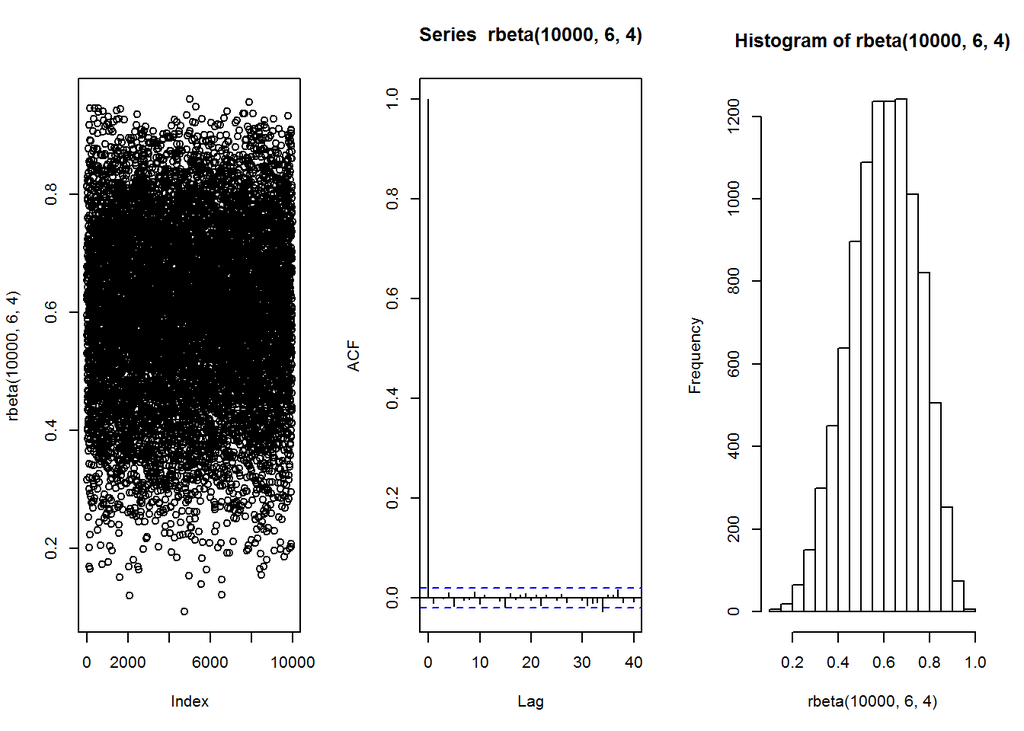

```r
par(mfrow=c(1,3))
plot(rbeta(10000, 6, 4)); acf(rbeta(10000, 6, 4)); hist(rbeta(10000, 6, 4))
```

Then, I plot a trace plot of this sampler and an autocorrelation plot, as well as a histogram of the draws by setting different c’s

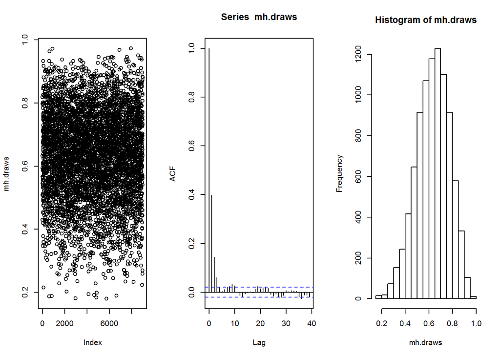

```r
mh.draws <- mh.beta(10000, startvalue = runif(1), burnin = 1000, shape1 = 6, shape2 = 4, c=1)
par(mfrow=c(1,3))  #1 row, 3 columns
 plot(mh.draws); acf(mh.draws); hist(mh.draws)  #plot commands
```

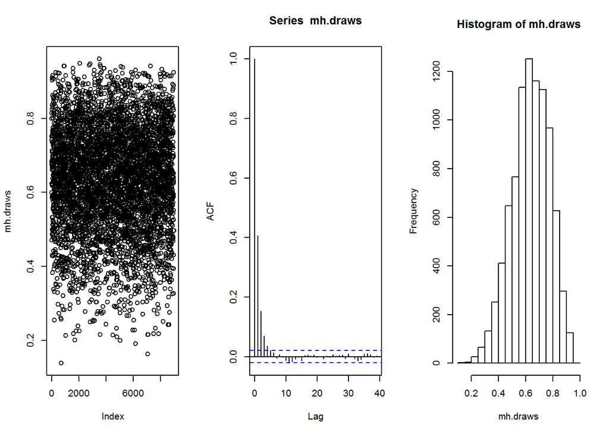

```r
mh.draws <- mh.beta(10000, startvalue = runif(1), burnin = 1000, shape1 = 6, shape2 = 4, c=0.1)
par(mfrow=c(1,3))  #1 row, 3 columns
 plot(mh.draws); acf(mh.draws); hist(mh.draws)  #plot commands
```

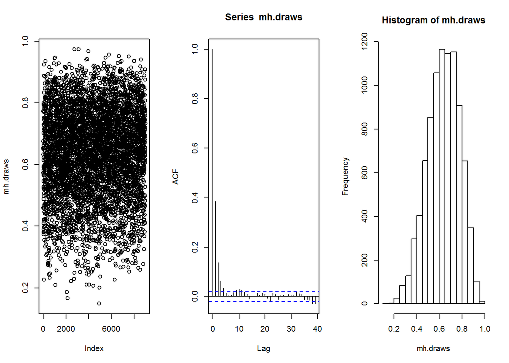

```r
mh.draws <- mh.beta(10000, startvalue = runif(1), burnin = 1000, shape1 = 6, shape2 = 4, c=2.5)
par(mfrow=c(1,3))  #1 row, 3 columns
 plot(mh.draws); acf(mh.draws); hist(mh.draws)  #plot commands
```

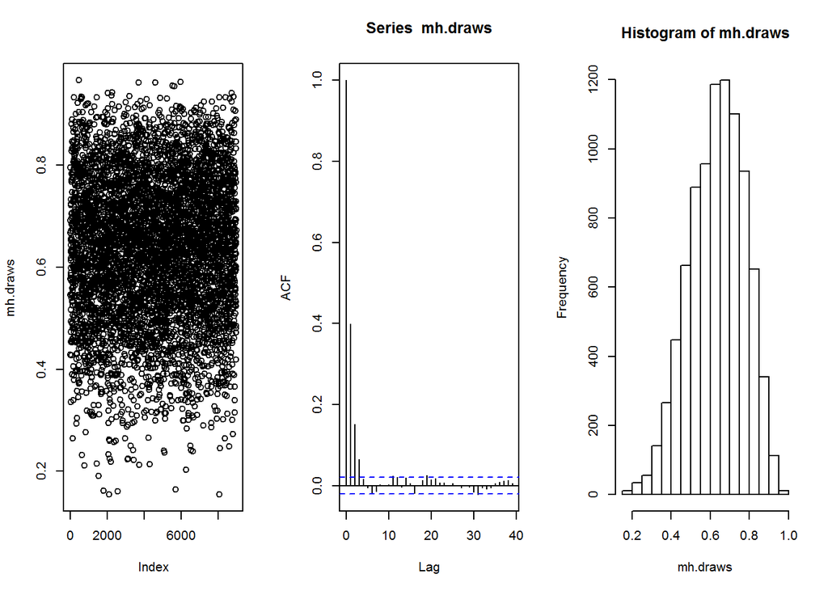

```r
mh.draws <- mh.beta(10000, startvalue = runif(1), burnin = 1000, shape1 = 6, shape2 = 4, c=10)
par(mfrow=c(1,3))  #1 row, 3 columns
 plot(mh.draws); acf(mh.draws); hist(mh.draws)  #plot commands
```

From the comparison of these draws, c = 2.5 is probably the best model within the above models.

$\textbf{Question 2 Gibbs sampling}$ Firstly, I set $h = h(x) = ye^{-yx}$. So the inverse function is $x = h^{-1}(x) = -\frac{1}{y}\log{(\frac{h}{y})}$. And similiarly, $g = g(y) = xe^{-yx}$. So the inverse function is $y = g^{-1}(y) = -\frac{1}{x}\log{(\frac{g}{x})}$. The code for the inverse function is shown below, with setting $0 < x, y < B = 5$

```r
 x <- 1
 y <- 1
invcdfh <- function(h,y,B=5) {
  while( x < B){
  return((-1/y)*log(h/y))
}
}

invcdfg <- function(g,x,B=5) {
  while( y < B){
  return((-1/x)*log(g/x))
}
}
```

The algorithm of the Gibbs Sampling is as the follow,

```r
gibbs<-function (n)
{
  sampleh <- sapply(runif(n), invcdfh, y)
  sampleg <- sapply(runif(n), invcdfg, x)
  mat <- matrix(ncol = 2, nrow = n)

  mat[1, ] <- c(x, y)
  for (i in 2:n) {
    x <- sampleh[i]
    y <- sampleg[i]
    mat[i, ] <- c(x, y)
  }
  mat
}
```

The histgrams of Gibbs with different sample sizes, T = 500, 5000 and 50000

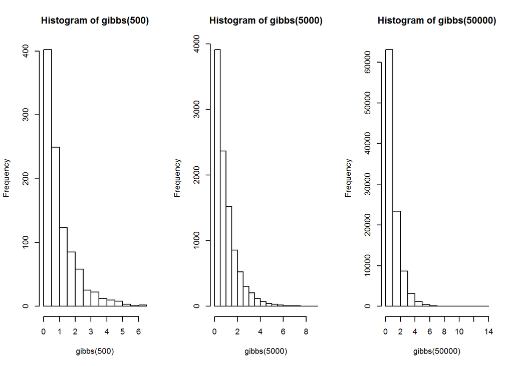

```r
par(mfrow=c(1,3))
hist(gibbs(500))  #plot commands
hist(gibbs(5000))  #plot commands
hist(gibbs(50000))  #plot commands
```

Now, we need to consider the moments of marginal distribution. We have $\mu_{x} = \frac{1}{M}\sum_{i=1}^M x_i^{N} P(x = x_{i})$

```r
#N is the N-th degree, T is the iteration
moment <- function(N,T){
  sampleh <- sapply(runif(T), invcdfh, y)
  sig <- (sampleh[1])^N*y*exp(-y*sampleh[1])
  for(j in 2:T){
    mome <- (sampleh[j])^N*y*exp(-y*sampleh[j])
  sig <- sig + mome
  }
  sig/T
}
```

For the expectation of x, we set N = 1, T = 500, 5000, 50000

```r
expect1 <- moment(1,500)
expect2 <- moment(1,5000)
expect3 <- moment(1,50000)
c(expect1, expect2, expect3)
```

```
## [1] 0.2542024 0.2495233 0.2502744
```

$\textbf{Question 3 K-Means}$ Firstly, we try the Wine model without scaling

```r
#install.packages('rattle',repos = "http://cran.us.r-project.org")
data(wine, package="rattle")

data.train.un <- wine[-1]
#Since the first column in the dataframe is the type of wine(1,2,3), so we need to rule it out of the model.

#install.packages('NbClust',repos = "http://cran.us.r-project.org")
library(NbClust)
nc <- NbClust(data.train.un, min.nc=2, max.nc=15, method="kmeans")
```

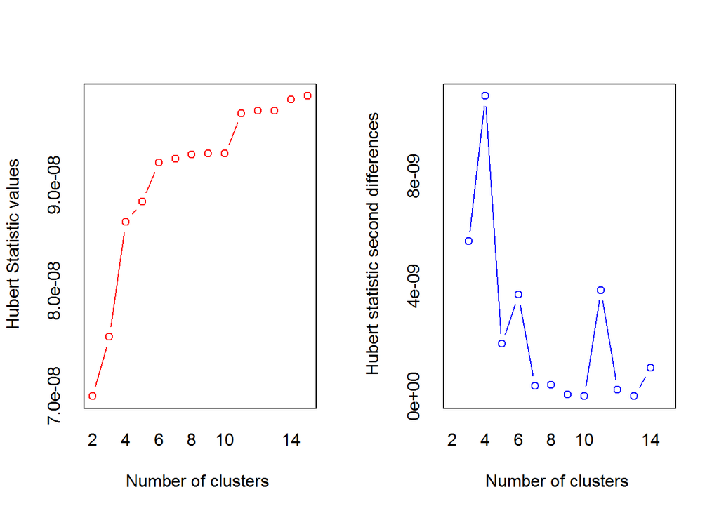

```
## *** : The Hubert index is a graphical method of determining the number of clusters.
##                 In the plot of Hubert index, we seek a significant knee that corresponds to a
##                 significant increase of the value of the measure i.e the significant peak in Hubert
##                 index second differences plot.
##
```

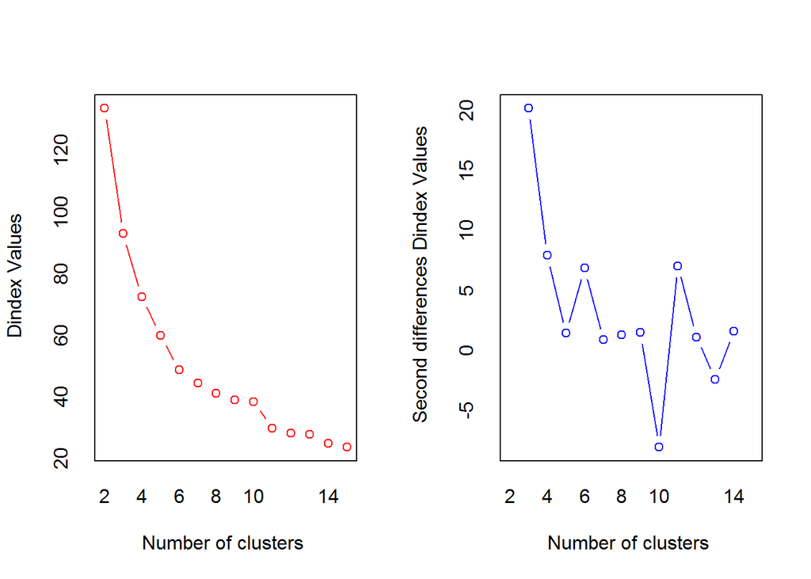

```
## *** : The D index is a graphical method of determining the number of clusters.
##                 In the plot of D index, we seek a significant knee (the significant peak in Dindex
##                 second differences plot) that corresponds to a significant increase of the value of
##                 the measure.
##
## * Among all indices:
## * 10 proposed 2 as the best number of clusters
## * 3 proposed 3 as the best number of clusters
## * 1 proposed 4 as the best number of clusters
## * 1 proposed 5 as the best number of clusters
## * 1 proposed 9 as the best number of clusters
## * 1 proposed 10 as the best number of clusters
## * 4 proposed 11 as the best number of clusters
## * 1 proposed 12 as the best number of clusters
## * 1 proposed 14 as the best number of clusters
## * 1 proposed 15 as the best number of clusters
##
##                    ***** Conclusion *****
##
## * According to the majority rule, the best number of clusters is  2
##
##
```

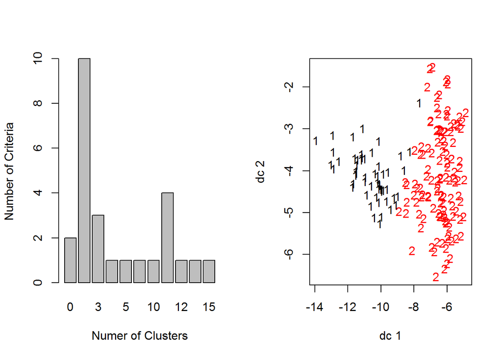

```r
barplot(table(nc$Best.n[1,]), xlab="Numer of Clusters", ylab="Number of Criteria")
#According to the method, we can find the best number of clusters is 2.
#We now fit wine data to K-Means with k = 2

fit.km.un <- kmeans(data.train.un, 2)

library(fpc)
plotcluster(data.train.un, fit.km.un$cluster)
```

```r
#We can see the data is not clustered very well.

library(MASS)
parcoord(data.train.un, fit.km.un$cluster)

confuseTable.km.un <- table(wine$Type, fit.km.un$cluster)
confuseTable.km.un
```

[output not shown]

```
##
##      1  2
##   1 50  9
##   2  4 67
##   3  1 47
```

```r
#install.packages('flexclust',repos = "http://cran.us.r-project.org")
library(flexclust)
randIndex(confuseTable.km.un)
```

```
##       ARI
## 0.3694075
```